# CLL Cytokine Screen 2021: Figure 3

Holly Giles and Peter Bruch

14 Juli 2022

# 1 Figure 3

In this sub-vignette we present the analysis and source code for Figure 3. This sub-vignette can be built along with all others by running CLLCytokineScreen2021.Rmd.

## 1.1 Set up

```r
set.seed(1996)
```

Load libraries

```r
library(clusterProfiler)
library(TxDb.Hsapiens.UCSC.hg19.knownGene)
library(ChIPseeker)
library(genomation)
library(DESeq2)
library(ggbeeswarm)
library(ggpubr)
library(magrittr)
library(gtable)
library(glmnet)
library(patchwork)
library(scales)
library(gridExtra)
library(ggrepel)
library(broom)
library(plyr)
library(tidyverse)
```

Set plot directory

```r
plotDir = ifelse(exists(".standalone"), "", "../../inst/figs/")
if(plotDir!="") if(!file.exists(plotDir)) dir.create(plotDir)
```

## 1.2 Load data

Load raw files

```r
#df : tibble containing all screening data
load( "../../data/df.RData")

#patMeta : tibble containing all patient genetic data
load( "../../data/patMeta.RData")
```

```r
#From tsvs
#df: tibble containing all screening data
df <- read.table(file= "../../inst/extdata/df.txt",header = TRUE) %>% as_tibble()

#patMeta: tibble containing genetic data for patient samples in screen
patMeta <- read.table(file= "../../inst/extdata/patMeta.txt",header = TRUE) %>% as_tibble()



#Arrange data for analysis
#screening data
df$Cytokine <- factor(df$Cytokine, levels= c("No Cytokine",
                                              "Resiquimod",
                                              "IL-4",
                                              "TGF-b1",
                                              "IL-1b",
                                              "Interferon gamma",
                                              "SDF-1a",
                                              "sCD40L" ,
                                              "sCD40L+IL-4",
                                              "soluble anti-IgM",
                                              "CpG ODN",
                                              "IL-6",
                                              "IL-10",
                                              "IL-21",
                                              "HS-5 CM",
                                              "IL-15",
                                              "BAFF",
                                              "IL-2" ))


#patMeta
patMeta %>%mutate_at(vars(-PatientID), as.factor)
```

Process files

```r
#filter for stimuli - only treatments
df <- dplyr::filter(df,
                    Drug == "DMSO",
                    Cytokine != "No Cytokine")

patMeta$treatment <- as.factor(patMeta$treatment)
```

## 1.3 Define Aesthetics

```r
source("../../R/themes_colors.R")
```

## 1.4 Define functions

*runGlm*: to run multi-variant regression. This function takes a feature matrix `X` and a continuous response matrix `y`, to run lasso or ridge regularised regression. The function will run the `cv.glmnet` function for the chosen number of `repeats`, applying cross-fold validation using chosen number of `folds`.

```r
#select lasso or ridge
runGlm <- function(X, y, method = "lasso", repeats=30, folds = 3) {

  #set up objects
  modelList <- list()
  lambdaList <- c()
  varExplain <- c()

  #set up a matrix for values of coefficients, with a row for each feature, and a column for each repeat
  coefMat <- matrix(NA, ncol(X), repeats)

  #make row names = genetic features
  rownames(coefMat) <- colnames(X)

  #set alpha according to selected method
  if (method == "lasso"){
    alpha = 1
  } else if (method == "ridge") {
    alpha = 0
  }

  #Run cv.glmnet for chosen number of repeats
  for (i in seq(repeats)) {

    #if there are more than two features, fit a glm
    if (ncol(X) > 2) {

      res <- cv.glmnet(X,y, type.measure = "mse", family="gaussian",
                       nfolds = folds, alpha = alpha, standardize = FALSE)

      #add lambda min from this repeat to the list of lambdas
      lambdaList <- c(lambdaList, res$lambda.min)

      #put the res object (with lambdas) into the list of models
      modelList[[i]] <- res

      #extract the coefficients for each feature, for lambda.min
      coefModel <- coef(res, s = "lambda.min")[-1] #remove intercept row

      #put these coefficients into  column of coefMatrix corresponding to the repeat
      coefMat[,i] <- coefModel

      #calculate variance explained
      y.pred <- predict(res, s = "lambda.min", newx = X)
      varExp <- cor(as.vector(y),as.vector(y.pred))^2
      varExplain[i] <- ifelse(is.na(varExp), 0, varExp)



    } else {
      #if there are only two features, fit a linear model
      fitlm<-lm(y~., data.frame(X))
      varExp <- summary(fitlm)$r.squared
      varExplain <- c(varExplain, varExp)

    }

  }
  #gather all lists
  list(modelList = modelList, lambdaList = lambdaList, varExplain = varExplain, coefMat = coefMat)
}
```

*makelegends*: to make legends for heatmap plot. Accepts`legendFor`, a vector of names of what the legend should show (I (IGHV status), M (Methylation Cluster), G (Gene Mutation)), and `colors`, a vector of colours corresponding to the elements of `legendFor`.

```r
makelegends <- function (legendFor, colors) {

    x = NULL
    y = NULL
    colors = colors[names(colors) %in% legendFor]
    nleg = length(colors)

    #set up gtable
    wdths = c(0.4,2,2,2,1.5)
    hghts = c(2)

    gtl = gtable(widths=unit(wdths, "in"), heights=unit(hghts, "in"))
    n = 2

    #legend for Methylation Cluster
    if ("M" %in% names(colors)) {
        Mgg = ggplot(data = data.frame(x = 1,
                                       y = factor(c("LP", "IP", "HP"),
                                                  levels = c("LP", "IP", "HP"))),
                     aes(x = x, y = y, fill = y)) +
              geom_tile() +
              scale_fill_manual(name = "Methylation cluster",
                                values = setNames(colors[["M"]],
                                                  nm = c("LP", "IP","HP"))) +
              theme(legend.title = element_text(size = 12),
                    legend.text = element_text(size = 12))

        gtl = gtable_add_grob(gtl, gtable_filter(ggplotGrob(Mgg), "guide-box"), 1, n)
        n = n + 1
    }

    #Legend for IGHV status
    if ("I" %in% names(colors)) {
        Igg = ggplot(data = data.frame(x = 1, y = factor(c("Unmutated",
            "Mutated"), levels = c("Unmutated", "Mutated"))),
            aes(x = x, y = y, fill = y)) + geom_tile() + scale_fill_manual(name = "IGHV",
            values = setNames(colors[["I"]], nm = c("Unmutated", "Mutated"))) +
            theme(legend.title = element_text(size = 12),
                  legend.text = element_text(size = 12))
        gtl = gtable_add_grob(gtl, gtable_filter(ggplotGrob(Igg),
            "guide-box"), 1, n)
        n = n + 1
    }

    #legend for gene mutations
    if ("G" %in% names(colors)) {
        Ggg = ggplot(data = data.frame(x = 1, y = factor(c("Wild Type",
            "Mutated"), levels = c("Wild Type", "Mutated"))),
            aes(x = x, y = y, fill = y)) + geom_tile() + scale_fill_manual(name = "Gene",
            values = setNames(colors[["G"]], nm = c("Wild Type", "Mutated"))) +
            theme(legend.title = element_text(size = 12),
                  legend.text = element_text(size = 12))
        gtl = gtable_add_grob(gtl, gtable_filter(ggplotGrob(Ggg),
            "guide-box"), 1, n)
        n = n + 1
    }

    return(list(plot = gtl, width = sum(wdths), height = sum(hghts)))
}
```

*lassoPlot*: to generate predictor profiles using output of `runGlm` function. Accepts `lassoOut`, a list of objects generated by `runGlm`, `geneMatrix` a feature matrix containing numeric data of mutation status for various genes, `viabMatrix`, a response matrix containing viability data for corresponding samples to those in `geneMatrix`, `freqCut`, the proportion of times a coefficient should be selected to be displayed in the plot, and `coefCut`, the minimum size of coefficients to display in the plot.

```r
lassoPlot <- function(lassoOut, geneMatrix, viabMatrix, freqCut = 1, coefCut = 0.01) {

  plotList <- list()

  for (seaName in names(lassoOut)) {
    ###FOR THE BAR PLOT
    #extract coefMat for each stimulus
    barValue <- rowMeans(lassoOut[[seaName]]$coefMat)
    #extract proportion of repeats for which each coefficient is significant
    freqValue <- rowMeans(abs(sign(lassoOut[[seaName]]$coefMat)))
    #filter out coefficients that don't meet freqCut and coefCut thresholds
    barValue <- barValue[abs(barValue) >= coefCut & freqValue >= freqCut]
    #arrange the bar values in numerical order
    barValue <- barValue[order(barValue)]
    #if there are no sig coefficients, don't plot
    if(length(barValue) == 0) {
      plotList[[seaName]] <- NA
      next
    }

    ###FOR THE HEATMAP AND SCATTER PLOT
    #get feature matrix and response matrix to plot
    allData <- geneMatrix
    viabValue <- unlist(viabMatrix[seaName,])

    #get feature matrix for sig coefficients only
    tabValue <- allData[, names(barValue),drop=FALSE]
    ord <- order(viabValue)
    viabValue <- viabValue[ord]
    tabValue <- tabValue[ord, ,drop=FALSE]
    sampleIDs <- rownames(tabValue)
    tabValue <- as_tibble(tabValue)
    tabValue$Sample <- sampleIDs


    #annotate mutations by mutation, methylation or IGHV
    matValue <- gather(tabValue, key = "Var",value = "Value", -Sample)
    matValue$Type <- "mut"

    #for Methylation Cluster
    matValue$Type[grep("Methylation",matValue$Var)] <- "meth"

    #for IGHV status
    matValue$Type[grep("IGHV",matValue$Var)] <- "ighv"

    #change the scale of the value so that IGHV, Methylation and Mutation do not overlap
    matValue[matValue$Type == "mut",]$Value = matValue[matValue$Type == "mut",]$Value + 10
    matValue[matValue$Type == "meth",]$Value = matValue[matValue$Type == "meth",]$Value + 20
    matValue[matValue$Type == "ighv",]$Value = matValue[matValue$Type == "ighv",]$Value + 30

    #change continuous to categorical
    matValue$Value <- factor(matValue$Value,levels = sort(unique(matValue$Value)))

    #arrange order of heatmap
    matValue$Var <- factor(matValue$Var, levels = names(barValue))
    matValue$Sample <- factor(matValue$Sample, levels = names(viabValue))

    #change labels if mutation is a Doehner mutation
    matValue$Var <- revalue(matValue$Var, c("del11q" = "del(11q)", "del13q" = "del(13q)", "del17p" = "del(17p)", "trisomy12" = "trisomy 12"))



     #plot the heatmap
      #title
    if(seaName=="TGF-b1"){
      thetitle <- "TGF-\u03B21"
      } else {
        if(seaName=='IL-4'){
          thetitle <- "IL4"
          } else {
            thetitle <- seaName
          }
        }

      p1 <- ggplot(matValue, aes(x=Sample, y=Var)) +
            geom_tile(aes(fill=Value), color = "white") + #ghost white
            theme_bw()+
            scale_y_discrete(expand=c(0,0)) +
            theme(axis.title.y = element_text( size=14),
                  axis.title.x = element_text( size=14),
                  axis.text.x=element_text(hjust=0, size=11),
                  axis.text.y=element_text(hjust=0.1, size=11),
                  axis.ticks=element_blank(),
                  panel.border=element_rect(colour="gainsboro"),
                  plot.title=element_text(face="bold", size = 18, margin = margin(t = -5, b = 1)),
                  panel.background=element_blank(),
                  panel.grid.major=element_blank(),
                  panel.grid.minor=element_blank()) +
            xlab("Mutation status for each patient") +
            ylab("") +
            scale_fill_manual(name="Mutated",
                              values=c(`10`= offwhite,  #WT
                                       `11`="#373A36", #Mutant
                                       `20`= offwhite, #LP
                                       `20.5`= "#707372", #IP
                                       `21` = "#A8A99E", #HP
                                       `30` = offwhite, #IGHV-U
                                       `31` = "#707372"), #IGHV-M
                                       guide="none") +
            ggtitle(thetitle)



    #Plot the bar plot on the left of the heatmap
    barDF = data.frame(barValue, nm=factor(names(barValue),levels=names(barValue)))

    p2 <- ggplot(data=barDF, aes(x=nm, y=barValue)) +
      geom_bar(stat="identity",
               fill=ifelse(barValue<0,
                           palblues[6],palreds[8]),
               colour="black",
               size=0.3) +
      scale_x_discrete(expand=c(0,0.5)) +
      scale_y_continuous(expand=c(0,0)) +
      coord_flip(ylim=c(-0.3,0.35)) + #changed from min(barValue) and max(barValue)
      theme(panel.grid.major=element_blank(),
            panel.background=element_blank(),
            axis.ticks.y = element_blank(),
            panel.grid.minor = element_blank(),
            axis.text=element_text(size=11, angle = 45, hjust = 1, vjust = 1),
                axis.title = element_text(size=14),
            panel.border=element_blank()) +
      ylab("Size of predictor") +
      geom_vline(xintercept=c(0.5),
                 color="black",
                 size=0.6)

    #Plot the scatter plot under the heatmap
    scatterDF = data.frame(X=factor(names(viabValue),
                                    levels=names(viabValue)),
                           Y=unlist(viabValue))

    p3 <-
      ggplot(scatterDF, aes(x=X, y=Y)) +
      geom_point(shape=21,
                     fill="dimgrey",
                     colour="#707372", #dark grey
                     size=1.2) +
      theme_bw() +
      theme(panel.grid.minor=element_blank(),
                panel.grid.major.x=element_blank(),
                #axis.title.x=element_blank(),
                axis.ticks.x=element_blank(),
                axis.text.y=element_text(size=11),
                axis.title.x=element_text(size=14),
                panel.border=element_rect(colour="dimgrey", size=0.1),
                panel.background=element_rect(fill="white")) +
      xlab("Logarithm of relative viability for each sample")


    #Assemble all the plots togehter

    # construct the gtable
    wdths = c(0.2, 1.5, 0.2, 1.3*ncol(matValue), 1.5, 0.2)
    hghts = c(0.2, 0.2, 0.0020*nrow(matValue), 0.3, 1, 0.2)
    gt = gtable(widths=unit(wdths, "in"), heights=unit(hghts, "in"))

    ## make grobs
    gg1 = ggplotGrob(p1)
    gg2 = ggplotGrob(p2)
    gg3 = ggplotGrob(p3)

    ## fill in the gtable

    #HEATMAP
    #5:1 = "PREDICTORS"
    gt = gtable_add_grob(gt, gtable_filter(gg1, "panel"), 3, 4) # add heatmap
    gt = gtable_add_grob(gt, gtable_filter(gg1, "panel"), 3, 4) #add legend
    gt = gtable_add_grob(gt, gtable_filter(gg1, "title"), 1, 4) #add title to plot
    gt = gtable_add_grob(gt, gtable_filter(gg1, "axis-l"), 3, 5) # variable names
    gt = gtable_add_grob(gt, gtable_filter(gg1, "xlab-b"), 2, 4) # axis title

    #BARPLOT
    gt = gtable_add_grob(gt, gtable_filter(gg2, "panel"), 3, 2) # add barplot
    gt = gtable_add_grob(gt, gtable_filter(gg2, "axis-b"), 4, 2) # y axis for barplot
    gt = gtable_add_grob(gt, gtable_filter(gg2, "xlab-b"), 2, 2) # y lab for barplot


    #SCATTER PLOT
    gt = gtable_add_grob(gt, gtable_filter(gg3, "panel"), 5, 4) # add scatterplot
    gt = gtable_add_grob(gt, gtable_filter(gg3, "xlab-b"), 6, 4) # x label for scatter plot
    gt = gtable_add_grob(gt, gtable_filter(gg3, "axis-l"), 5, 3) #  axis for scatter plot




    #plot
    #grid.draw(gt)
    plotList[[seaName]] <- gt
  }
  return(plotList)
}
```

## 1.5 Plot Figures

### 1.5.1 Figure 3A

Overview of t test p values to identify genetic features that affect responses to stimuli.  
Here we test for associations between stimulus viability assay results and genomic features by Student’s t-tests (two-sided, with equal variance). We test somatic mutations (aggregated at the gene level), copy number aberrations and IGHV status. We restrict the analysis to features that are present in at least 3 patient samples (63 features). p-values are transformed using the Benjamini-Hochberg procedure.

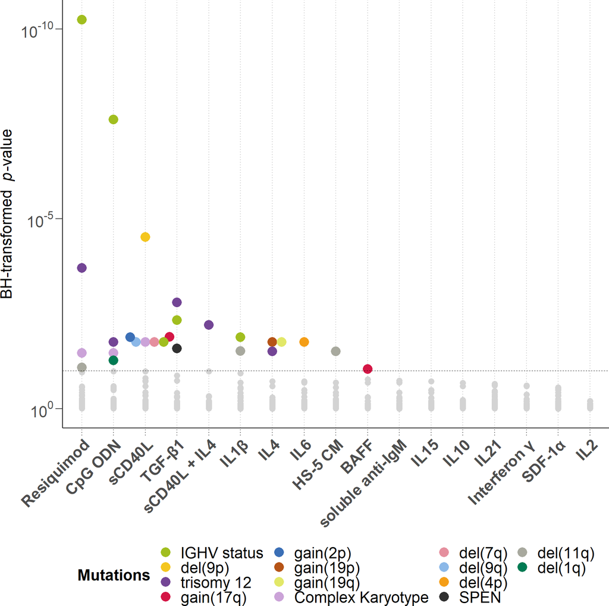

```r
##################### List of mutations with >2 postive cases #############################
selected_mutations <-
  patMeta %>%
  mutate(Ras_Raf=as.factor(ifelse(BRAF==1|KRAS==1|NRAS==1, 1,0))) %>%
  dplyr::select(-BRAF, -KRAS, -NRAS) %>%
  dplyr::select( -gender,
                 -diagnosis,
                 ) %>%
  pivot_longer(-PatientID,
               names_to="Genetic_Alteration",
               values_to = "alteration_value") %>%
  dplyr::filter(alteration_value %in% c(1, "U")) %>%
  dplyr::group_by(Genetic_Alteration) %>%
  dplyr::count() %>%
  dplyr::filter(n>2) %>%
  dplyr::select(Genetic_Alteration) %>%
  unlist()


## Calculate number of CNVs for each patient with compelte CNV annotation
CNVs<-  patMeta %>%
    select(PatientID, del10p:trisomy12) %>%
    pivot_longer(cols=del10p:trisomy12, names_to = "Chr_Aberration", values_to = "Value") %>%
    mutate(Value=as.numeric(levels(Value))[Value]) %>%
    group_by(PatientID) %>%
    summarise(CNVs=sum(Value)) %>%
  mutate(Complex_Karyotype3=as.factor(case_when(CNVs>2~1, CNVs<=2~0)),
         Complex_Karyotype5=as.factor(case_when(CNVs>4~1, CNVs<=4~0)),
         CNVs=NULL)


##################### t tests and p-value adjustment ###############################
p_values <-
  ## Select columns from screening data
  dplyr::select(df, PatientID, Log, Cytokine) %>%

  ## Join Screening data with metadata
  left_join(patMeta, by = "PatientID") %>%

  ## Add Ras/Raf column, remove single columns
  mutate(Ras_Raf=as.factor(ifelse(BRAF==1|KRAS==1|NRAS==1, 1,0))) %>%
  dplyr::select(-BRAF, -KRAS, -NRAS) %>%

    ## Add Complex Caryotype column, remove single columns
  left_join(CNVs, by = "PatientID") %>%

## remove unused columns from metadata
  dplyr::select( -gender,
                 -diagnosis,
                 -treatment) %>%

  ## transform data to long format
  pivot_longer(cols=c(-PatientID, -Log, -Cytokine),
               names_to = "Genetic_alt",
               values_to="alt_value") %>%

  ## filter to selected mutations (see above)
  dplyr::filter(Genetic_alt%in%c(selected_mutations, "Complex_Karyotype3")) %>%


  ## group by Cytokine and Genetic alteration
  dplyr::group_by(Cytokine, Genetic_alt) %>%

  ## Perform t.test on every combination of Cytokine and genetic alteration
  do(tidy(t.test(Log ~ alt_value, data = ., var.equal = T))) %>%

  ## ungroup before adjusting p-value
  ungroup() %>%

  ## adjust p-values to multiple testing using BH method
  mutate(adj.p.value=p.adjust(p.value, method = "BH"))


################################## Order of cytokines by descending significance ############################
Cytokine_order <-
  p_values %>%
  dplyr::group_by(Cytokine) %>%
  dplyr::arrange(adj.p.value) %>%
  dplyr::filter(row_number()==1) %>%
  ungroup() %>%
  dplyr::arrange(adj.p.value) %>%
  dplyr::select(Cytokine) %>%
  unlist()

Genetic_alt_order <-
  p_values %>%
  dplyr::group_by(Genetic_alt) %>%
  dplyr::arrange(adj.p.value) %>%
  dplyr::filter(row_number()==1) %>%
  ungroup() %>%
  dplyr::arrange(adj.p.value) %>%
  dplyr::select(Genetic_alt) %>%
  unlist()

############################# Define FDR cutoff #################################
fdr = 0.1


############################################ Plot ########################################
p_values %<>%
  mutate(Cytokine=factor(Cytokine, levels = Cytokine_order)) %>%
  mutate(Genetic_alt=factor(Genetic_alt, levels = Genetic_alt_order))

Fig3A<-  ggplot(dplyr::filter(p_values, adj.p.value>fdr),
         aes(x = Cytokine, y = -log10(adj.p.value))) +
  geom_point(color = "lightgrey", size=3) +
  geom_beeswarm(data = dplyr::filter(p_values, adj.p.value<=fdr),
                aes( color=Genetic_alt), size=5, cex=1.7) +
  ##FDR line
  geom_hline(yintercept = -log10(fdr),linetype="dashed", size=0.3)+

  ##Main Theme
  t1 +

  theme(axis.text.x = element_text(angle=45,
                                   size=18,
                                   face="bold",
                                   hjust=1,
                                   vjust=1),
        axis.title.x=element_blank()) +
  ##Legend Theme
  theme(legend.position="bottom",
        legend.title = element_text(face='bold', hjust = 0, size=18),
        legend.key = element_blank(),
        legend.text = element_text(size=18)) +
  guides(colour = guide_legend(nrow=4, title = "Mutations"),
         shape = "none") +
  scale_color_manual(name = "Mutations", values = c(colors, "black"), labels=c("IGHV.status"="IGHV status", "del9p"="del(9p)", "trisomy12"="trisomy 12", "gain17q"="gain(17q)", "gain2p"="gain(2p)","gain19p"="gain(19p)","gain19q"="gain(19q)", "del7q"="del(7q)","del9q"="del(9q)", "del4p"= "del(4p)", "SPEN"="SPEN", "del11q"="del(11q)", "del1q" = "del(1q)", "Complex_Karyotype3"="Complex Karyotype")) +
  scale_y_continuous(expression("BH-transformed  "* italic(p)*"-value"),
                     breaks=seq(0,10,5),
                     labels=math_format(expr=10^.x)(-seq(0,10,5)))+
  scale_x_discrete(labels=c("TGF-b1"="TGF-\u03B21", "sCD40L+IL-4"="sCD40L + IL4", "IL-1b"="IL1\u03B2", "IL-4"="IL4", "IL-6"="IL6","IL-15"="IL15","IL-10"="IL10", "IL-21"="IL21","IL-2"="IL2", "Interferon gamma"= "Interferon \u03B3", "SDF-1a"="SDF-1\u03B1"))

Fig3A
```

Print significant p-values for text reference.

```r
pvals <-
  p_values %>%
  dplyr::rename(cyt=Cytokine, mutation=Genetic_alt)

p_values %>%
  dplyr::filter(adj.p.value<0.1) %>%
  dplyr::select(Cytokine, Genetic_alt, adj.p.value) %>%
  dplyr::arrange(adj.p.value) %>%
  DT::datatable()
```

|  | Cytokine | Genetic_alt | adj.p.value |
| --- | --- | --- | --- |
| 1 | Resiquimod | IGHV.status | 5.64172385356874e-11 |
| 2 | CpG ODN | IGHV.status | 2.43996256302204e-08 |
| 3 | sCD40L | del9p | 3.04196666121813e-05 |
| 4 | Resiquimod | trisomy12 | 0.000198529314974987 |
| 5 | TGF-b1 | trisomy12 | 0.00160045981111314 |
| 6 | TGF-b1 | IGHV.status | 0.00467376812451369 |
| 7 | sCD40L+IL-4 | trisomy12 | 0.00625321817073169 |
| 8 | sCD40L | gain17q | 0.0129723468662801 |
| 9 | sCD40L | gain2p | 0.0130272766965254 |
| 10 | IL-1b | IGHV.status | 0.0132359800955058 |

[output cut: 17 more lines]

### 1.5.2 Figure 3B

```r
#Generate Matrix

#select features from patient meta file
geneMatrix <-
  dplyr::select(patMeta,
                -c(gender:treatment)) %>%

  #adjust IGHV.status levels  U and M to numeric 1 and 0
  mutate(IGHV = ifelse(is.na(IGHV.status), NA,
                       ifelse(IGHV.status == "M", 1, 0)),
         #adjust Methylation_Cluster levels  LP, IP, HP to 0, 0.5, 1
         Methylation = ifelse(is.na(Methylation_Cluster), NA,
                              ifelse(Methylation_Cluster == "LP", 0,
                                     ifelse(Methylation_Cluster == "IP", 0.5, 1))),
         #remove old columns
         IGHV.status=NULL, Methylation_Cluster=NULL ) %>%

  #rename columns for labelling

  #rename("del(11q)" = del11q) %>%
  #rename("del(13q)" = del13q) %>%
  #rename("del(17p)" = del17p) %>%
  #rename("trisomy 12" = trisomy12) %>%

  #convert factors to numeric
  mutate_if(is.factor, as.character) %>%
  mutate_at(vars(-PatientID), as.numeric) %>%

  #convert to matrix format, with patient IDs as rownames
  data.frame() %>%
  column_to_rownames("PatientID") %>%
  as.matrix()


#Tidy matrix for use in glmnet function

#Remove genes with higher than 20% missing values
geneMatrix <- geneMatrix[,colSums(is.na(geneMatrix))/nrow(geneMatrix) <= 0.2]

#Filter for patients with complete data
geneMatrix.complete <- geneMatrix[complete.cases(geneMatrix),]


#Combine KRAS, NRAS and BRAF mutations into a single column
#set up empty matrix
Ras_Raf <- matrix(NA,
                  nrow = nrow(geneMatrix.complete),
                  ncol = 1)

colnames(Ras_Raf) <- "RAS/RAF"

#add RAS/RAF column to matrix
geneMatrix.complete <- cbind(geneMatrix.complete, Ras_Raf)

#Annotate RAS_RAF where where any of KRAS, NRAS or BRAF are mutated
geneMatrix.complete[,"RAS/RAF"] <- ifelse(geneMatrix.complete[,"KRAS"]==1,1,
                                                ifelse(geneMatrix.complete[,"BRAF"]==1,1,
                                                  ifelse(geneMatrix.complete[,"NRAS"]==1, 1, 0)))


#remove KRAS, NRAS and BRAF columns
geneMatrix.complete <-
  geneMatrix.complete[, colnames(geneMatrix.complete) != "KRAS"]

geneMatrix.complete <-
  geneMatrix.complete[, colnames(geneMatrix.complete) != "BRAF"]

geneMatrix.complete <-
  geneMatrix.complete[, colnames(geneMatrix.complete) != "NRAS"]

str(geneMatrix.complete)
```

```
##  num [1:129, 1:41] 0 0 0 1 0 0 0 0 0 0 ...
##  - attr(*, "dimnames")=List of 2
##   ..$ : chr [1:129] "Pat_001" "Pat_002" "Pat_003" "Pat_004" ...
##   ..$ : chr [1:41] "del11q" "del12q" "del13q" "del17p" ...
```

Set up viability response matrix

```r
viabMatrix <-
  #select patients with complete meta data
  dplyr::filter(df,
                PatientID %in% row.names(geneMatrix.complete)) %>%
  #select cytokine, patient and log( viability values only)
  dplyr::select(Cytokine,
                Log,
                PatientID) %>%
  #reshape data
  spread(key = PatientID, value = Log) %>%
  data.frame() %>%
  #make Cytokine the row names
  remove_rownames() %>%
  column_to_rownames("Cytokine")

#make sample order same as in geneMatrix
viabMatrix <- viabMatrix[,rownames(geneMatrix.complete)]
```

Run lasso regression

```r
#set object to hold model outputs
dataResult <- list()

#fit model for each stimulus
for (i in rownames(viabMatrix)){

    #prepare input and response matrices
    y <- unlist(viabMatrix[i,]) # viability for each patient with given condition
    X <- geneMatrix.complete #genetic features for each patient

    #fit the model
    cvglmfit <- runGlm(X, y, method="lasso", repeats=30, folds=3)

    #collect the results for each stimulus in one object
    dataResult[[i]] <- cvglmfit

}

save(dataResult, geneMatrix.complete, viabMatrix,  file = "../../data/fig3_data_for_lassoplots.RData")
```

Get predictor profiles for stimuli of interest

```r
heatMaps_cyt <- lassoPlot(dataResult[c("IL-4","CpG ODN", "TGF-b1")] ,  #
                          geneMatrix.complete, #use gene matrix for heatmap
                          viabMatrix, #use viab matrix for scatter plot
                          freqCut = 0.75, #coefficients should be selected in <75% of bootstrapped model files
                          coefCut = 0.02) #no minimum value for coefficients
```

Assemble legend for heatmaps

```r
#G = gene mutations, I = IGHV, M = Methylation Cluster
legendFor = c("G", "I", "M")

#assign colours for I, G and M
coldef<-list()
coldef["I"] <- list(c(offwhite,"#707372")) #U-CLL and M-CLL
coldef["M"] <- list(c(offwhite, "#707372", "#A8A99E")) #IP, HP, LP
coldef["G"] <- list(c(offwhite, "#373A36")) #WT and Mutated


legends = makelegends(legendFor=c("G","I","M"),coldef)
```

Assemble figure

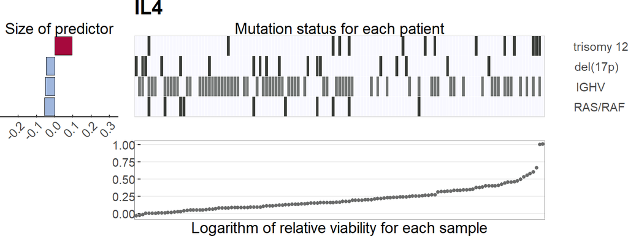

```r
Fig3B_1 <- wrap_elements(grid.arrange( grobs = heatMaps_cyt[1], ncol =1))
```

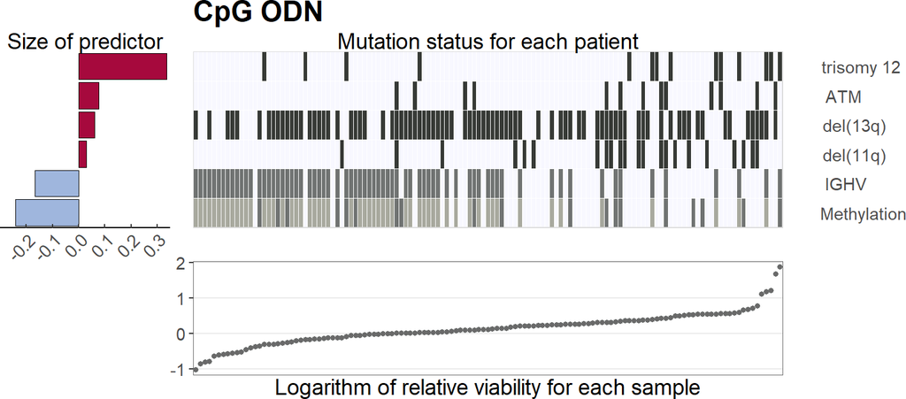

```r
Fig3B_2 <- wrap_elements(grid.arrange( grobs = heatMaps_cyt[2], ncol =1))
```

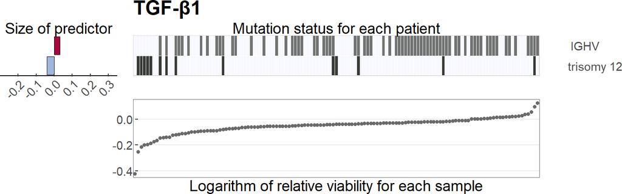

```r
Fig3B_3 <- wrap_elements(grid.arrange( grobs = heatMaps_cyt[3], ncol =1))
```

```r
Fig3B_leg <- legends[["plot"]] %>% wrap_elements()
```

## 1.6 Assemble Figure

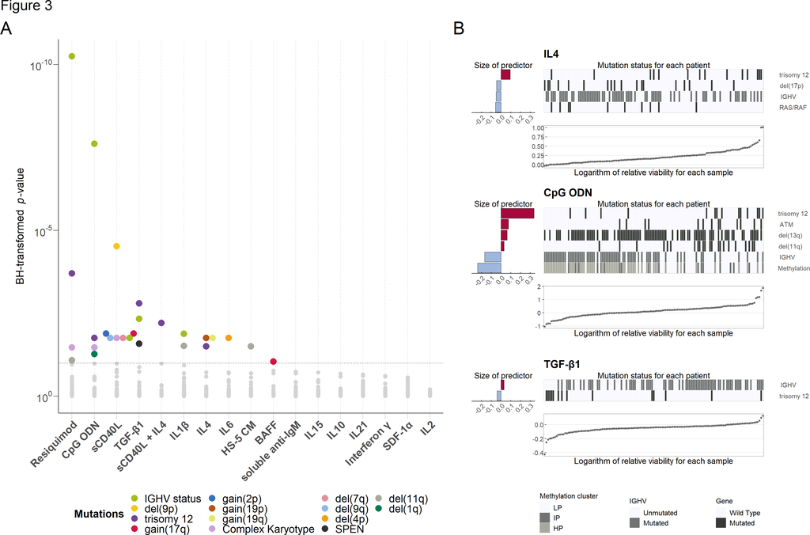

```r
design1<-"
  AB
"

blankplot <-
  ggplot() +
  geom_blank() +
  theme(panel.background = element_blank())

tp <- theme(plot.tag=element_text(size = 30))

Fig3 <-
  wrap_elements(Fig3A) + tp +

   wrap_elements(Fig3B_1 +
                Fig3B_2+
                Fig3B_3+
                wrap_elements(blankplot + # add a blank space before legend to align with plots above
                                Fig3B_leg +
                                plot_layout(ncol=2, widths  = c(0.15,0.9))) +
                  plot_layout(ncol=1,
                              heights = c(1.7,1.7,1.7,0.5)))+tp +


  plot_annotation(tag_levels = "A", title="Figure 3", theme = theme(title=element_text(size = 20)))+
  plot_layout(design = design1, width=c(2,1.7))

Fig3
```

```r
# ggsave(Fig3, device = cairo_pdf, filename = "../../inst/figs/Fig3.pdf", width = 20, height = 13, units="in", dpi="screen")
```

## 1.7 Additional Figure for Revision

### 1.7.1 Adjusted Figure 3A with FDR of 5%

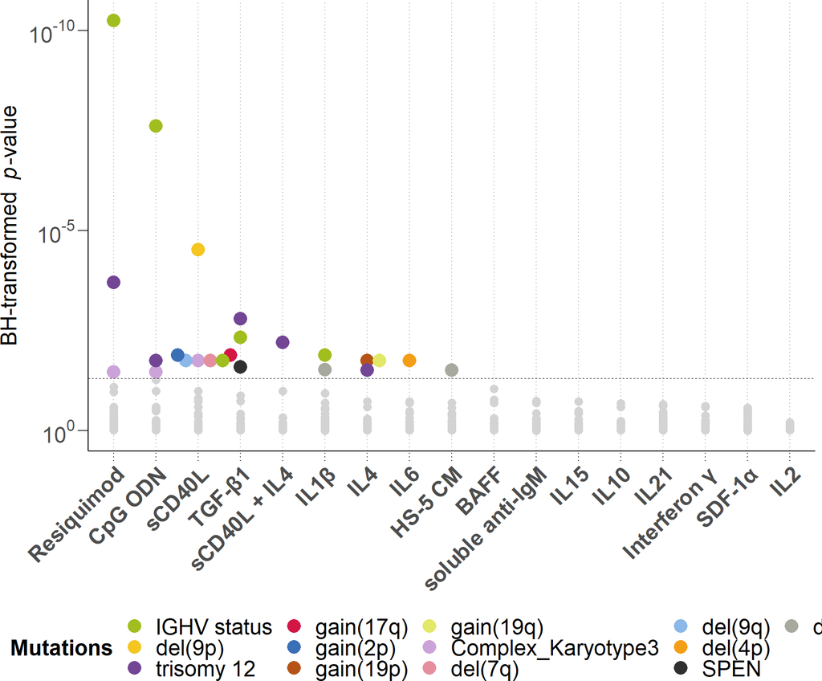

```r
############################# Define FDR cutoff #################################
fdr = 0.05


############################################ Plot ########################################
p_values %<>%
  mutate(Cytokine=factor(Cytokine, levels = Cytokine_order)) %>%
  mutate(Genetic_alt=factor(Genetic_alt, levels = Genetic_alt_order))


  ggplot(dplyr::filter(p_values, adj.p.value>fdr),
         aes(x = Cytokine, y = -log10(adj.p.value))) +
  geom_point(color = "lightgrey", size=3) +
  geom_beeswarm(data = dplyr::filter(p_values, adj.p.value<=fdr),
                aes( color=Genetic_alt), size=5, cex=1.7) +
  ##FDR line
  geom_hline(yintercept = -log10(fdr),linetype="dashed", size=0.3)+

  ##Main Theme
  t1 +

  theme(axis.text.x = element_text(angle=45,
                                   size=18,
                                   face="bold",
                                   hjust=1,
                                   vjust=1),
        axis.title.x=element_blank()) +
  ##Legend Theme
  theme(legend.position="bottom",
        legend.title = element_text(face='bold', hjust = 0, size=18),
        legend.key = element_blank(),
        legend.text = element_text(size=18)) +
  guides(colour = guide_legend(nrow=3, title = "Mutations"),
         shape = guide_legend(ncol = 1)) +
  scale_color_manual(name = "Mutations", values = colors, labels=c("IGHV.status"="IGHV status", "del9p"="del(9p)", "trisomy12"="trisomy 12", "gain17q"="gain(17q)", "gain2p"="gain(2p)","gain19p"="gain(19p)","gain19q"="gain(19q)", "del7q"="del(7q)","del9q"="del(9q)", "del4p"= "del(4p)", "SPEN"="SPEN", "del11q"="del(11q)", "del1q" = "del(1q)")) +
  scale_y_continuous(expression("BH-transformed  "* italic(p)*"-value"),
                     breaks=seq(0,10,5),
                     labels=math_format(expr=10^.x)(-seq(0,10,5)))+
  scale_x_discrete(labels=c("TGF-b1"="TGF-\u03B21", "sCD40L+IL-4"="sCD40L + IL4", "IL-1b"="IL1\u03B2", "IL-4"="IL4", "IL-6"="IL6","IL-15"="IL15","IL-10"="IL10", "IL-21"="IL21","IL-2"="IL2", "Interferon gamma"= "Interferon \u03B3", "SDF-1a"="SDF-1\u03B1"))
```

## 1.8 Appendix

```r
Sys.info()
```

```
##           sysname           release           version          nodename
##         "Windows"          "10 x64"     "build 19044" "DESKTOP-NR9H6QL"
##           machine             login              user    effective_user
##          "x86-64"     "Peter Bruch"     "Peter Bruch"     "Peter Bruch"
```